# TP-03 Javier Duque

## 1.Preparación de los datos

### a) Leer el archivo titanic_complete_train.csv y mostrar su estructura

Comenzamos leyendo el dataframe y se muestra la estructura de las variables, el tipo de datos

```r
#Se cargan las librerias a usar
library(readr)
library(tidyverse)
library(broom)
library(GGally)
library(modelr)
library(pROC)
library(cowplot)
library(OneR)
library(rlang)
library(caret)
```

```r
#Se lee el dataset y se procede a revisar la estructura de los datos
titanic_complete_train <- read_csv("C:/Users/Jad/Documents/Maestria DM/Enfoque estadistico del aprendizaje/EEA2019JD/EEA2019/TP-3/titanic_complete_train.csv")
glimpse(titanic_complete_train)
```

```
Observations: 891
Variables: 12
$ PassengerId <dbl> 1, 2, 3, 4, 5, 6, 7, 8, 9, 10, 11, 12, 13, 14, 15, 16, 17, 18, 19, 20, ...
$ Survived    <dbl> 0, 1, 1, 1, 0, 0, 0, 0, 1, 1, 1, 1, 0, 0, 0, 1, 0, 1, 0, 1, 0, 1, 1, 1,...
$ Pclass      <dbl> 3, 1, 3, 1, 3, 3, 1, 3, 3, 2, 3, 1, 3, 3, 3, 2, 3, 2, 3, 3, 2, 2, 3, 1,...
$ Name        <chr> "Braund, Mr. Owen Harris", "Cumings, Mrs. John Bradley (Florence Briggs...
$ Sex         <chr> "male", "female", "female", "female", "male", "male", "male", "male", "...
$ Age         <dbl> 22.00000, 38.00000, 26.00000, 35.00000, 35.00000, 26.50759, 54.00000, 2...
$ SibSp       <dbl> 1, 1, 0, 1, 0, 0, 0, 3, 0, 1, 1, 0, 0, 1, 0, 0, 4, 0, 1, 0, 0, 0, 0, 0,...
$ Parch       <dbl> 0, 0, 0, 0, 0, 0, 0, 1, 2, 0, 1, 0, 0, 5, 0, 0, 1, 0, 0, 0, 0, 0, 0, 0,...
$ Ticket      <chr> "A/5 21171", "PC 17599", "STON/O2. 3101282", "113803", "373450", "33087...
$ Fare        <dbl> 7.2500, 71.2833, 7.9250, 53.1000, 8.0500, 8.4583, 51.8625, 21.0750, 11....
$ Cabin       <chr> NA, "C85", NA, "C123", NA, NA, "E46", NA, NA, NA, "G6", "C103", NA, NA,...
$ Embarked    <chr> "S", "C", "S", "S", "S", "Q", "S", "S", "S", "C", "S", "S", "S", "S", "...
```

### b) Seleccionar las variables PassengerId, Survived, Pclass, Sex, Age, SibSp,Parch, Fare y Embarked

```r
#Se realiza la seleccion de variables que se desan
titanic_data_train <- titanic_complete_train %>%
  select(.,c("PassengerId", "Survived", "Pclass", "Sex", "Age", "SibSp","Parch", "Fare", "Embarked"))
```

### c) Transformar las variables Survived, Pclass y Embarked a factor

```r
#Las variables Survived, Pclass, Embarked se convierten a factor
titanic_data_train$Survived <- as.factor(titanic_data_train$Survived)
titanic_data_train$Pclass <- as.factor(titanic_data_train$Pclass)
titanic_data_train$Embarked <- as.factor(titanic_data_train$Embarked)
```

### d) Realizar un gráfico de ggpairs para las variables Survived, Pclass, Sex, Age y Fare e interpretarlo

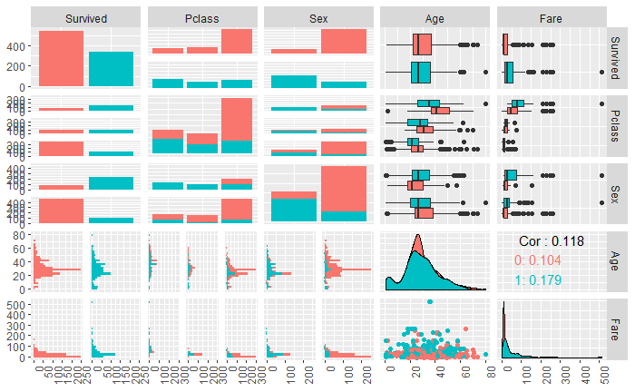

```r
# Realizar grafico ggpairs para las variables Survived, Pclass, Sex, Age y Fare
titanic_data_graph <- titanic_data_train%>%
  select(c("Survived","Pclass","Sex", "Age", "Fare"))
ggpairs(titanic_data_graph,  mapping = aes(color = Survived))+
  theme(axis.text.x = element_text(angle = 90, hjust = 1)) +
  theme_grey()+
  theme(legend.position = "bottom")
```

Se puede observar que hay una correlacion muy baja entre las variables Age y Fare, analizando el grafico se puede ver que la variable Pclass, Sexo pueden ser buenas para predecir, la Pclass corresponde a la clase en la que viajaba el pasajero.

### e) Mostrar la distribución de clase (Sobrevivientes vs No Sobrevivientes)

```r
#Ver la distribucion de las clases de la variable survived
titanic_data_train %>%
  group_by(Survived) %>%
  summarise(numero_casos=n())
```

| Survived | numero_casos |
| --- | --- |
| 0 | 549 |
| 1 | 342 |

Se observa que la clase que se quiere predecir se encuentra balanceada.

### f) Dividir al dataset en conjunto de entrenamiento (70% de los datos) y validación (30% de los datos). Volver a analizar la distribución de clase para chequear que este balanceado

```r
#Dividir el dataset en entrenamiento 70% y test 30%
titanic_train_test <- titanic_data_train %>% resample_partition(c(train=0.7,test=0.3))

train_data <- titanic_train_test$train %>% as_tibble()
test_data <- titanic_train_test$test %>% as_tibble()
```

```r
#Ver distribucion de las clases en survived
train_data %>%
  group_by(Survived) %>%
  summarise(numero_casos=n())
```

| Survived | numero_casos |
| --- | --- |
| 0 | 376 |
| 1 | 247 |

Al realizar la division del dataset se observa que la clase aun continua estando balanceada

## 2. Predicciones (Trabajar con dataset de ENTRENAMIENTO)

### a) Realizar un modelo de regresión logística para predecir la supervivencia en función de Pclass, Sex y Age. Usar solo el dataset de entrenamiento

```r
#Se realiza una regresion logistica en funcion de Pclass, Sex y Age con el dataset de entrenamiento
modelo1 <- glm(Survived ~ Pclass + Sex + Age, family = "binomial", data = train_data )
summary(modelo1)
```

```
Call:
glm(formula = Survived ~ Pclass + Sex + Age, family = "binomial",
    data = train_data)

Deviance Residuals:
    Min       1Q   Median       3Q      Max
-2.6999  -0.6581  -0.4419   0.6375   2.4037

Coefficients:
             Estimate Std. Error z value Pr(>|z|)
(Intercept)  3.689642   0.459884   8.023 1.03e-15 ***
Pclass2     -1.144861   0.320989  -3.567 0.000362 ***
Pclass3     -2.377622   0.303253  -7.840 4.49e-15 ***
Sexmale     -2.570529   0.222150 -11.571  < 2e-16 ***
Age         -0.035755   0.009348  -3.825 0.000131 ***
---
Signif. codes:  0 ‘***’ 0.001 ‘**’ 0.01 ‘*’ 0.05 ‘.’ 0.1 ‘ ’ 1

(Dispersion parameter for binomial family taken to be 1)

    Null deviance: 836.76  on 622  degrees of freedom
Residual deviance: 567.24  on 618  degrees of freedom
AIC: 577.24

Number of Fisher Scoring iterations: 4
```

### b) Dar una breve interpretación de los coeficientes y su significatividad

El modelo eligio como categorias basales en la variable Sex = Female y Pclass = Clase 1, se puede ver que si hay un cambio de la variable Pclass la cual indica la clase a la que pertenece el pasajero su probabilidad de sobrevivir disminuiria, lo mismo sucede si el pasajero es de sexo masculino tambien se presenta una disminucin de su propabilidad de sobrevivir disminuye tambien. Para el coeficiente de la variable Age = -0.0357548 lo que indica es que si aumenta un año la edad del pasajero su probabilidad de sobrevivir disminuye.

En cuanto a la signifcatividad se puede observar que todas las variables son significativas para el modelo

### c) ¿Quién tiene una mayor probabilidad de supervivencia? Rose que es una mujer de 17 años que viaja en primera clase o Jack que es un hombre de 20 años viajando en tercera clase

```r
# Se crean las dos observaciones nuevas
Rose =  data.frame( Sex = "female",
                    Age = 17,
                    Pclass = factor(1)
                    )

Jack =  data.frame( Sex = "male",
                    Age = 20,
                    Pclass = factor(3)
                    )
#Se realiza la prediccion y se muestran los resultados
predicciones <- predict(modelo1, Rose, type = "response")
predicciones %>%
  bind_rows(predict(modelo1, Jack, type = "response"))
```

| 1 |
| --- |
| 0.9561362 |
| 0.1220022 |

La mayor probabilidad para sobrevivir la tendria Rose con una probabilidad de 0.9561362

## 3) Generación de modelos (Trabajar con dataset de ENTRENAMIENTO)

### a) Generar 3 modelos de regresión logística sobre el dataset de entrenamiento utilizando diferentes combinaciones de variables. Al menos dos modelos deben ser multivariados

```r
#Crear la funcion para luego aplicar los modelos
logit_formulas <- formulas(.response = ~Survived,
                         sex= ~Sex,
                         class_sex_fare= ~Pclass+Sex+Fare,
                         full= ~Pclass+Sex+Age+Fare,
                         )
#armar el dataframe con los modelos
modelos2 <- data_frame(logit_formulas) %>%
  mutate(modelos = names(logit_formulas),
         expression = paste(logit_formulas),
         mod2 = map(logit_formulas, ~glm(.,family = 'binomial', data = train_data)))

modelos2 %>%
  mutate(tidy = map(mod2,tidy)) %>%
  unnest(tidy, .drop = TRUE) %>%
  mutate(estimate=round(estimate,5),
         p.value=round(p.value,4))
```

| modelos | expression | term | estimate | std.error | statistic | p.value |
| --- | --- | --- | --- | --- | --- | --- |
| sex | Survived ~ Sex | (Intercept) | 1.15367 | 0.157544485 | 7.3228337 | 0.0000 |
| sex | Survived ~ Sex | Sexmale | -2.56188 | 0.201431034 | -12.7183805 | 0.0000 |
| class_sex_fare | Survived ~ Pclass + Sex + Fare | (Intercept) | 2.23816 | 0.340518503 | 6.5728137 | 0.0000 |
| class_sex_fare | Survived ~ Pclass + Sex + Fare | Pclass2 | -0.70625 | 0.330936630 | -2.1341050 | 0.0328 |
| class_sex_fare | Survived ~ Pclass + Sex + Fare | Pclass3 | -1.74199 | 0.300639889 | -5.7942755 | 0.0000 |
| class_sex_fare | Survived ~ Pclass + Sex + Fare | Sexmale | -2.64845 | 0.221441411 | -11.9600369 | 0.0000 |
| class_sex_fare | Survived ~ Pclass + Sex + Fare | Fare | 0.00117 | 0.002779554 | 0.4194400 | 0.6749 |
| full | Survived ~ Pclass + Sex + Age + Fare | (Intercept) | 3.74912 | 0.537874718 | 6.9702437 | 0.0000 |
| full | Survived ~ Pclass + Sex + Age + Fare | Pclass2 | -1.17958 | 0.359821070 | -3.2782478 | 0.0010 |
| full | Survived ~ Pclass + Sex + Age + Fare | Pclass3 | -2.41817 | 0.357848983 | -6.7575240 | 0.0000 |

[output cut: 3 more lines]

### b) Ordenar por la deviance los 3 modelos creados en el punto 3)a) y el creado en el punto 2)a) y seleccionar el mejor modelo en términos de la deviance explicada

```r
# Calcular las medidas de evaluación para cada modelo
# Obtengo las medidas de evaluacion para el modelo de 2a)
modelos1 <- bind_cols(expression = "Survived ~ Pclass + Sex + Age")
modeloadd <- as.data.frame(glance(modelo1))
modelos1 <- modelos1 %>%
  bind_cols(modeloadd)

modelos1 <- modelos1 %>%
  # Calculo de la deviance explicada
  mutate(perc_explained_dev = 1-deviance/null.deviance) %>%
  select(-c(df.null, AIC, BIC))

#obtengo las medidas de evaluacion para el modelo 3a)
modelos2 <- modelos2 %>%
  mutate(glance = map(mod2,glance))

# Obtener las medidas de evaluacion de interes
modelos2 %>%
  unnest(glance, .drop = TRUE) %>%
  # Calculo de la deviance explicada
  mutate(perc_explained_dev = 1-deviance/null.deviance) %>%
  select(-c(modelos, df.null, AIC, BIC)) %>%
  bind_rows(modelos1) %>%
  arrange(deviance)
```

| expression | null.deviance | logLik | deviance | df.residual | perc_explained_dev |
| --- | --- | --- | --- | --- | --- |
| Survived ~ Pclass + Sex + Age + Fare | 836.7561 | -283.5948 | 567.1896 | 617 | 0.3221566 |
| Survived ~ Pclass + Sex + Age | 836.7561 | -283.6177 | 567.2353 | 618 | 0.3221019 |
| Survived ~ Pclass + Sex + Fare | 836.7561 | -291.3511 | 582.7022 | 618 | 0.3036176 |
| Survived ~ Sex | 836.7561 | -320.9482 | 641.8964 | 621 | 0.2328751 |

Se elije el modelo con las variables Pclass, Sex, Age aunque no es el que tiene mayor deviance, se diferencia muy poco del modelo con todas las variables, y al analizar la significatvidad de la variable Fare en los modelos esta presenta un p_valor muy alto lo cual no la hace significativa.

## 4)Evaluación del modelo (Trabajar con dataset de ENTRENAMIENTO)

### a) Realizar el gráfico de curva ROC y obtener el AUC para el modelo elegido. Interpretar el gráfico

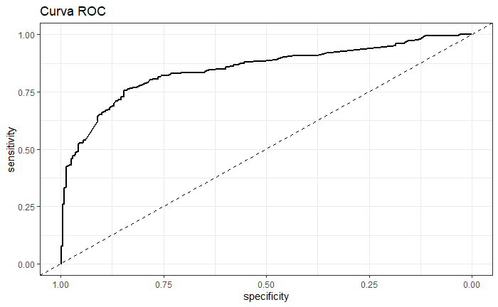

```r
#Crear la funcion para luego aplicar los modelos
logit_formulas2 <- formulas(.response = ~Survived,
                         elect= ~Pclass+Sex+Age,
                         )
#armar el dataframe con los modelos
modeloelegido <- data_frame(logit_formulas2) %>%
  mutate(modeloelegido = names(logit_formulas2),
         expression = paste(logit_formulas2),
         mod = map(logit_formulas2, ~glm(.,family = 'binomial', data = train_data)))
# Añadir las predicciones
modeloelegido <- modeloelegido %>%
  mutate(pred= map(mod,augment, type.predict = "response"))

prediction <- modeloelegido %>%
  filter(modeloelegido=="elect") %>%
  unnest(pred, .drop=TRUE)

roc <- roc(response=prediction$Survived, predictor=prediction$.fitted)
ggroc(data = roc, size=1) + geom_abline(slope = 1, intercept = 1, linetype='dashed') + theme_bw() + labs(title='Curva ROC')
```

Los ejes de la curva muestran el trade-off presente entre dos métricas como lo son la sensitividad, es decir la proporción del total de positivos (sobrevivientes) que el algoritmo clasificó correctamente como tales, y la especificidad, que es, por el contrario, la proporción del total de negativos (no sobrevivientes) que nuestra regresión clasificó correctamente como tales, a medida que se va variando el punto de corte. Esto es, como se ve en la gráfica, conforme nos movemos por la curva, para ganar en sensitividad (clasificar más positivos correctamente, los TP) necesariamente debemos ir reduciendo nuestra especificidad (clasificar más positivos incorrectamente, los FP).

### b) Realizar un violin plot e interpretar

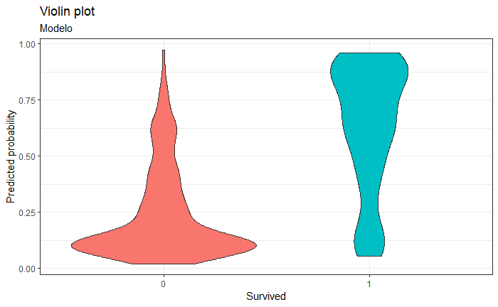

```r
violinelect=ggplot(prediction, aes(x=Survived, y=.fitted, group=Survived,fill=factor(Survived))) +
  geom_violin() +
  theme_bw() +
  guides(fill=FALSE) +
  labs(title='Violin plot', subtitle='Modelo', y='Predicted probability')

plot_grid(violinelect)
```

Este contrasta en forma clara y elegante la clase real a la que pertenece cada individuo y la probabilidad predicha por nuestro modelo de regresión logística. Queda reforzada aquí lo dicho sobre la bondad de nuestro modelo ya que se observa que las probabilidades arrojadas para valores pertenecientes a la clase de No Supervivencia (aquí 0) tienen una concentración grande cerca del 0, afinandose a medida que crece la probabilidad, mientras que las probabilidades arrojadas por el modelo para aquellos valores originales pertenecientes a la clase de Supervivencia (aquí 1) se concentran más arriba, cercanas al 1, y se hace cada vez menos poblada conforme se baja en el eje de y de probabilidades.

## 5) Elección del punto corte (Trabajar con dataset de VALIDACION)

### a) Sobre el dataset de validación realizar un gráfico de Accuracy, Specificity, Recall y Precision en función del punto de corte

```r
# Añadimos predicciones pero esta vez del dataset de validación
modelo_val <- modeloelegido %>%
 mutate(pred = map(mod, augment, newdata = test_data, type.predict = "response"))

# Obtenemos las correspondientes a nuestro mejor modelo
prediction_validation <- modelo_val %>%
  unnest(pred, .drop = TRUE)
```

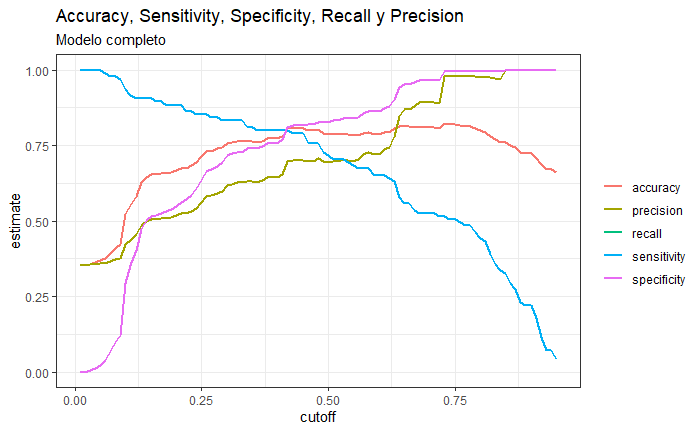

```r
prediction_metrics <- function(cutoff, predictions=prediction_validation){
  table <- predictions %>%
    mutate(predicted_class=if_else(.fitted>cutoff, 1, 0) %>% as.factor(),
           Survived= factor(Survived))

  confusionMatrix(table$predicted_class, table$Survived, positive = "1") %>%
    tidy() %>%
    select(term, estimate) %>%
    filter(term %in% c('accuracy', 'sensitivity', 'specificity', 'precision','recall')) %>%
    mutate(cutoff=cutoff)

}

cutoffs = seq(0.01,0.95,0.01)
logit_pred= map_dfr(cutoffs, prediction_metrics)%>% mutate(term=as.factor(term))

ggplot(logit_pred, aes(cutoff,estimate, group=term, color=term)) + geom_line(size=1) +
  theme_bw() +
  labs(title= 'Accuracy, Sensitivity, Specificity, Recall y Precision', subtitle= 'Modelo completo', color="")
```

### c) Obtener la matriz de confusión con el modelo y punto de corte elegidos. Interpretarla

```r
sel_cutoff = 0.41
# Creamos el modelo
elect_model <- glm(logit_formulas2$elect, family = 'binomial', data = test_data)
# Agregamos la predicciones al dataset de testeo
table <- augment(x=elect_model, newdata=test_data, type.predict='response')
# Clasificamos utilizamos el punto de corte
table <- table %>% mutate(predicted_class=if_else(.fitted>sel_cutoff, 1, 0) %>% as.factor(),
           Survived= factor(Survived))
# Creamos la matriz de confusión
confusionMatrix(table(table$Survived, table$predicted_class), positive = "1")
```

```
Confusion Matrix and Statistics


      0   1
  0 142  31
  1  20  75

               Accuracy : 0.8097
                 95% CI : (0.7575, 0.8549)
    No Information Rate : 0.6045
    P-Value [Acc > NIR] : 4.353e-13

                  Kappa : 0.5948

 Mcnemar's Test P-Value : 0.1614

            Sensitivity : 0.7075
            Specificity : 0.8765
         Pos Pred Value : 0.7895
         Neg Pred Value : 0.8208
             Prevalence : 0.3955
         Detection Rate : 0.2799
   Detection Prevalence : 0.3545
      Balanced Accuracy : 0.7920

       'Positive' Class : 1
```

## 6)Dataset de testeo (Trabajar con dataset de TESTEO)

### a) Leer el archivo titanic_complete_test.csv y transformar las variables Survived, Pclass y Embarked a factor

```r
#Se lee el dataset y se procede a revisar la estructura de los datos
titanic_complete_testeo <- read_csv("C:/Users/Jad/Documents/Maestria DM/Enfoque estadistico del aprendizaje/EEA2019JD/EEA2019/TP-3/titanic_complete_test.csv")
#Las variables Survived, Pclass, Embarked se convierten a factor
titanic_complete_testeo$Survived <- as.factor(titanic_complete_testeo$Survived)
titanic_complete_testeo$Pclass <- as.factor(titanic_complete_testeo$Pclass)
titanic_complete_testeo$Embarked <- as.factor(titanic_complete_testeo$Embarked)
glimpse(titanic_complete_testeo)
```

```
Observations: 418
Variables: 12
$ PassengerId <dbl> 892, 893, 894, 895, 896, 897, 898, 899, 900, 901, 902, 903, 904, 905, 9...
$ Pclass      <fct> 3, 3, 2, 3, 3, 3, 3, 2, 3, 3, 3, 1, 1, 2, 1, 2, 2, 3, 3, 3, 1, 3, 1, 1,...
$ Name        <chr> "Kelly, Mr. James", "Wilkes, Mrs. James (Ellen Needs)", "Myles, Mr. Tho...
$ Sex         <chr> "male", "female", "male", "male", "female", "male", "female", "male", "...
$ Age         <dbl> 34.50000, 47.00000, 62.00000, 27.00000, 22.00000, 14.00000, 30.00000, 2...
$ SibSp       <dbl> 0, 1, 0, 0, 1, 0, 0, 1, 0, 2, 0, 0, 1, 1, 1, 1, 0, 0, 1, 0, 1, 0, 0, 0,...
$ Parch       <dbl> 0, 0, 0, 0, 1, 0, 0, 1, 0, 0, 0, 0, 0, 0, 0, 0, 0, 0, 0, 0, 0, 1, 0, 1,...
$ Ticket      <chr> "330911", "363272", "240276", "315154", "3101298", "7538", "330972", "2...
$ Fare        <dbl> 7.8292, 7.0000, 9.6875, 8.6625, 12.2875, 9.2250, 7.6292, 29.0000, 7.229...
$ Cabin       <chr> NA, NA, NA, NA, NA, NA, NA, NA, NA, NA, NA, NA, "B45", NA, "E31", NA, N...
$ Embarked    <fct> Q, S, Q, S, S, S, Q, S, C, S, S, S, S, S, S, C, Q, C, S, C, C, S, S, C,...
$ Survived    <fct> 0, 1, 0, 0, 1, 1, 0, 1, 1, 0, 0, 0, 1, 0, 1, 1, 0, 0, 0, 0, 0, 1, 1, 1,...
```

### b)Con el modelo y punto de corte elegidos clasificar a las personas del dataset de testing.

```r
testeo <- augment(x = elect_model,newdata = titanic_complete_testeo, type.predict = 'response')
testeo <- testeo %>%
  mutate(predicted_class = if_else(.fitted >= sel_cutoff, 1, 0) %>%
           as.factor(),
         Survived = factor(Survived)
)
# Muestro la clasificación de cada persona
testeo %>%
  select(PassengerId, Sex, Age, .fitted,Pclass, predicted_class) %>%
  arrange(-.fitted)
```

| PassengerId | Sex | Age | .fitted | Pclass | predicted_class |
| --- | --- | --- | --- | --- | --- |
| 1074 | female | 18.00000 | 0.95736812 | 1 | 1 |
| 1287 | female | 18.00000 | 0.95736812 | 1 | 1 |
| 1123 | female | 21.00000 | 0.95213034 | 1 | 1 |
| 918 | female | 22.00000 | 0.95025237 | 1 | 1 |
| 1294 | female | 22.00000 | 0.95025237 | 1 | 1 |
| 904 | female | 23.00000 | 0.94830472 | 1 | 1 |
| 1042 | female | 23.00000 | 0.94830472 | 1 | 1 |
| 1256 | female | 25.00000 | 0.94419130 | 1 | 1 |
| 1164 | female | 26.00000 | 0.94202084 | 1 | 1 |
| 984 | female | 27.00000 | 0.93977136 | 1 | 1 |

[output cut: 408 more lines]

### c) Obtener la matriz de confusión y comparar con la obtenida en el punto 5)c).

```r
# Creamos la matriz de confusión
confusionMatrix(table(testeo$Survived, testeo$predicted_class), positive = "1")
```

```
Confusion Matrix and Statistics


      0   1
  0 206  55
  1  47 110

               Accuracy : 0.756
                 95% CI : (0.7119, 0.7964)
    No Information Rate : 0.6053
    P-Value [Acc > NIR] : 5.475e-11

                  Kappa : 0.485

 Mcnemar's Test P-Value : 0.4882

            Sensitivity : 0.6667
            Specificity : 0.8142
         Pos Pred Value : 0.7006
         Neg Pred Value : 0.7893
             Prevalence : 0.3947
         Detection Rate : 0.2632
   Detection Prevalence : 0.3756
      Balanced Accuracy : 0.7404

       'Positive' Class : 1
```